# 疯魔的时代，32万人，和他们的债务陷阱 —— 对拍拍贷借款人行为的观察

### 借款类型之间的差异

#### 借款类型 vs. 利率：电商借款产品利率较低

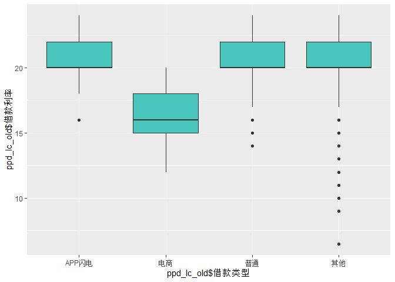

#### 借款类型 vs. 借款金额: 电商产品借款金额较高

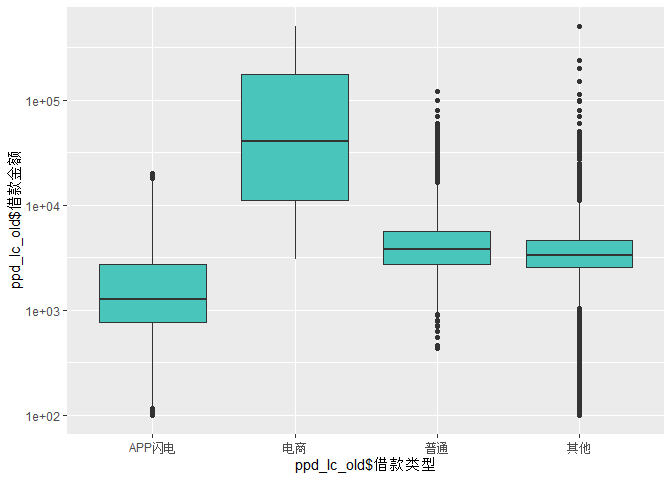

#### 借款类型 vs. 历史单笔借款金额: 电商类产品用户，历史单笔借款金额也较高

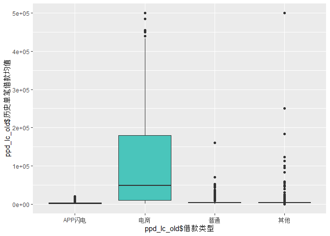

#### 借款类型 vs. 偿还率：电商产品用户在借入新款时，旧款偿还率较高

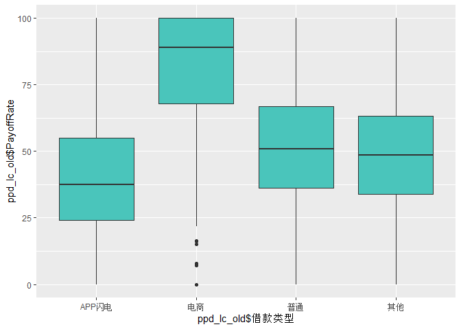

#### 借款类型vs. 旧债占总体债务比例：APP闪电贷用户旧债较高，电商用户占比较低

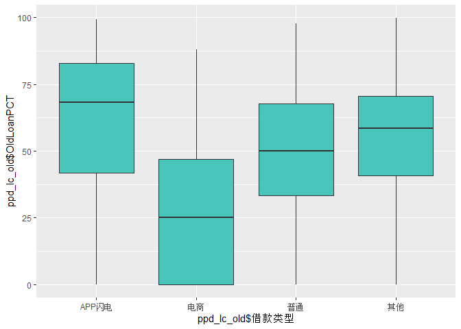

#### 借款类型 vs. 逾期率： APP闪电用户历史逾期率较低；普通和电商用户历史逾期率较高

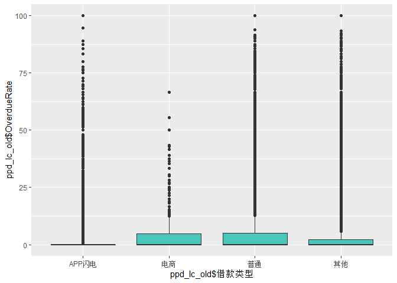

### 时间序列关联分析

#### 借款日期 vs. 借款类型：拍拍贷业务在15-17年之间的演变

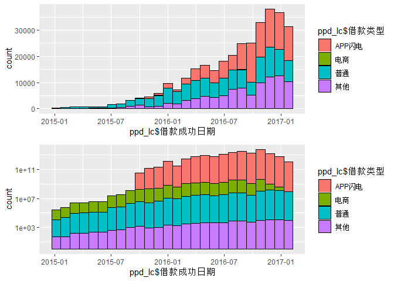

#### 借款日期 vs. 借款金额：2015年7月后，小额贷款（1000元以下）借款案例大幅增加；17年无1万及以上借款

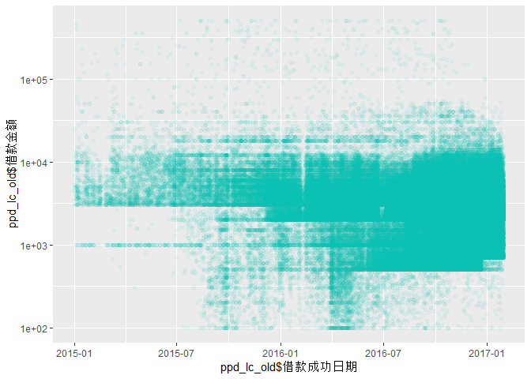

#### 借款日期 vs. 总待还金额：借款人负债范围越来越大，但平均负债水平基本稳定

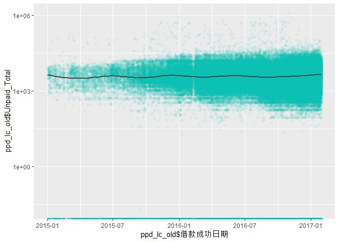

#### 借款日期 vs. 逾期率: 借款人历史逾期率范围不断扩大，但平均水平基本稳定

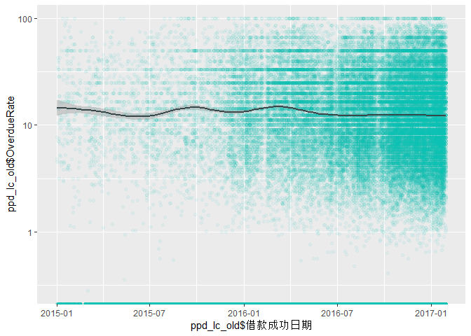

#### 借款日期 vs. 偿还率: 15年-16年4月，用户借款时平均偿还率水平不断降低；16年4月后基本稳定

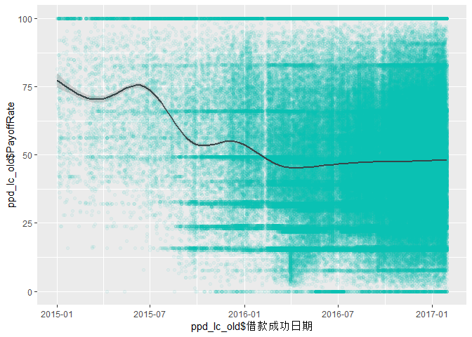

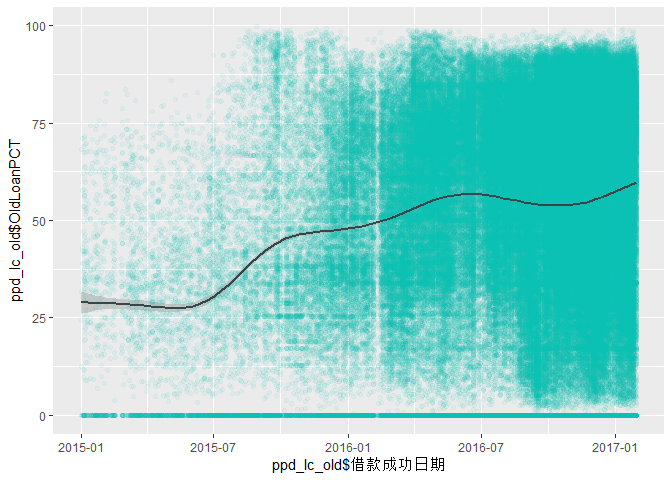

#### 借款成功日期 vs. 历史单笔借款均值

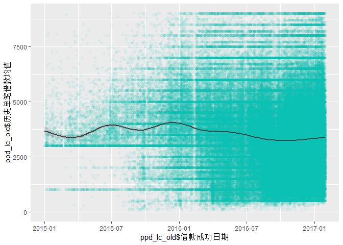

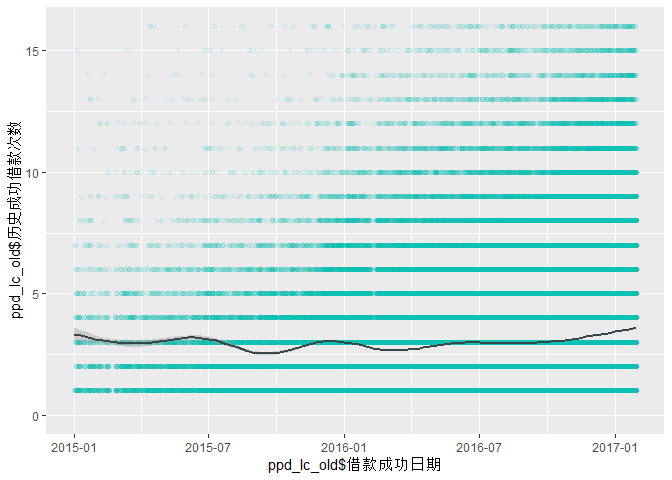

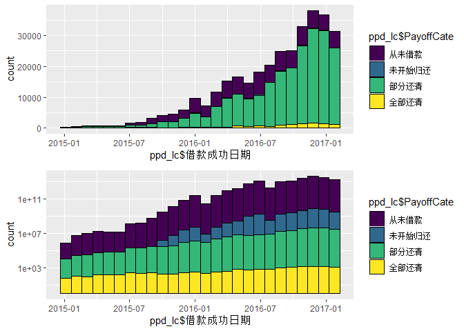

### 双变量分析：小结

在观察一系列双变量之间的关系后，我们有了如下发现：

#### 神秘的大额短期贷款

- 期限较短的借款反而额度较高，疑似资金过桥；借款数额在1000 - 10000之间的金额款期限反而在2-12个月；
- 借款期限为18-24个月的，似乎是针对个人的高额度贷款。

#### 压力山大的电商老板

- 电商借款产品利率较低
- 电商产品借款金额较高
- 电商类产品用户，历史单笔借款金额也较高
- 电商产品用户在借入新款时，旧款偿还率较高
- 电商用户占比较低，APP闪电贷用户旧债较高；这可能是APP闪电贷用户的资格决定的；
- 电商和普通用户历史逾期率较高，APP闪电用户历史逾期率较低；这可能是由于APP闪电贷用户本身就是更加优质用户的原因；

#### 进一步的探索

- 不同的借款类型的借款金额随时间的演变是否有不同的规律？
- 不同借款类型的借款人代表不同的用户群体，其借款时的负债状况随时间的演变是否不同？
- 借款时，借款人对旧债的偿还情况不同，是否会影响他们的借款行为？

## 多变量绘图选择

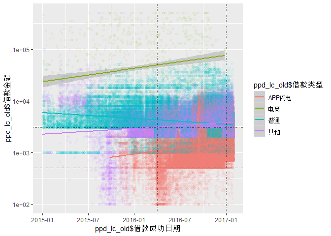

```
## [[1]]
##
## Call:
## lm(formula = I(log(LoanSum)) ~ Days, data = .)
##
## Coefficients:
## (Intercept)         Days
##    6.257108     0.001574
##
##
## [[2]]
##
## Call:
## lm(formula = I(log(LoanSum)) ~ Days, data = .)
##
## Coefficients:
## (Intercept)         Days
##   10.067760     0.001608
##
##
## [[3]]
##
## Call:
## lm(formula = I(log(LoanSum)) ~ Days, data = .)
##
## Coefficients:
## (Intercept)         Days
##   8.6815433   -0.0007175
##
##
## [[4]]
##
## Call:
## lm(formula = I(log(LoanSum)) ~ Days, data = .)
##
## Coefficients:
## (Intercept)         Days
##   7.7156872    0.0007093
```

```
## # A tibble: 8 x 6
## # Groups:   LoanType [4]
##   LoanType term          estimate std.error statistic      p.value
##   <fct>    <chr>            <dbl>     <dbl>     <dbl>        <dbl>
## 1 APP闪电  (Intercept)   6.26     0.0207       302.   0
## 2 APP闪电  Days          0.00157  0.0000318     49.4  0
## 3 电商     (Intercept)  10.1      0.127         79.5  0
## 4 电商     Days          0.00161  0.000298       5.40 0.0000000905
## 5 普通     (Intercept)   8.68     0.00815     1066.   0
## 6 普通     Days         -0.000718 0.0000142    -50.5  0
## 7 其他     (Intercept)   7.72     0.00788      979.   0
## 8 其他     Days          0.000709 0.0000127     56.1  0
```

```
## # A tibble: 4 x 12
## # Groups:   LoanType [4]
##   LoanType r.squared adj.r.squared sigma statistic p.value    df  logLik
##   <fct>        <dbl>         <dbl> <dbl>     <dbl>   <dbl> <int>   <dbl>
## 1 APP闪电     0.0291        0.0291 0.822    2443.  0.          2 -99697.
## 2 电商        0.0361        0.0349 1.51       29.1 9.05e-8     2  -1424.
## 3 普通        0.0360        0.0360 0.627    2552.  0.          2 -64953.
## 4 其他        0.0335        0.0335 0.484    3143.  0.          2 -62686.
## # ... with 4 more variables: AIC <dbl>, BIC <dbl>, deviance <dbl>,
## #   df.residual <int>
```

### 借款类型与借款人负债随时间的变化

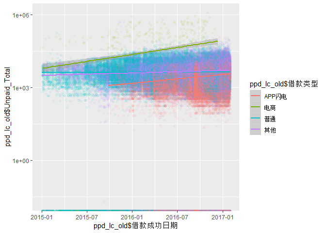

建立模型以评估不同类型的变化趋势

```
## [[1]]
##
## Call:
## lm(formula = I(Unpaid_Total) ~ Days, data = .)
##
## Coefficients:
## (Intercept)         Days
##   -1172.006        7.756
##
##
## [[2]]
##
## Call:
## lm(formula = I(Unpaid_Total) ~ Days, data = .)
##
## Coefficients:
## (Intercept)         Days
##    -14730.3        275.3
##
##
## [[3]]
##
## Call:
## lm(formula = I(Unpaid_Total) ~ Days, data = .)
##
## Coefficients:
## (Intercept)         Days
##    5193.589        1.151
##
##
## [[4]]
##
## Call:
## lm(formula = I(Unpaid_Total) ~ Days, data = .)
##
## Coefficients:
## (Intercept)         Days
##    3593.984        3.677
```

```
## # A tibble: 8 x 6
## # Groups:   LoanType [4]
##   LoanType term         estimate std.error statistic   p.value
##   <fct>    <chr>           <dbl>     <dbl>     <dbl>     <dbl>
## 1 APP闪电  (Intercept)  -1172.      78.6     -14.9   3.42e- 50
## 2 APP闪电  Days             7.76     0.120    64.4   0.
## 3 电商     (Intercept) -14730.   17927.       -0.822 4.12e-  1
## 4 电商     Days           275.      39.4       6.98  9.27e- 12
## 5 普通     (Intercept)   5194.      74.6      69.7   0.
## 6 普通     Days             1.15     0.129     8.94  3.97e- 19
## 7 其他     (Intercept)   3594.      91.2      39.4   0.
## 8 其他     Days             3.68     0.146    25.1   7.04e-139
```

```
## # A tibble: 4 x 12
## # Groups:   LoanType [4]
##   LoanType r.squared adj.r.squared  sigma statistic   p.value    df  logLik
##   <fct>        <dbl>         <dbl>  <dbl>     <dbl>     <dbl> <int>   <dbl>
## 1 APP闪电    0.0517        0.0517  2.99e3    4147.  0.            2 -7.17e5
## 2 电商       0.0885        0.0867  1.51e5      48.7 9.27e- 12     2 -6.72e3
## 3 普通       0.00125       0.00123 5.27e3      79.9 3.97e- 19     2 -6.40e5
## 4 其他       0.00724       0.00723 5.44e3     632.  7.04e-139     2 -8.68e5
## # ... with 4 more variables: AIC <dbl>, BIC <dbl>, deviance <dbl>,
## #   df.residual <int>
```

不错，能用~

### 借款时先前负债的归还情况，对同历史单笔借款均值的借款人借款金额的影响

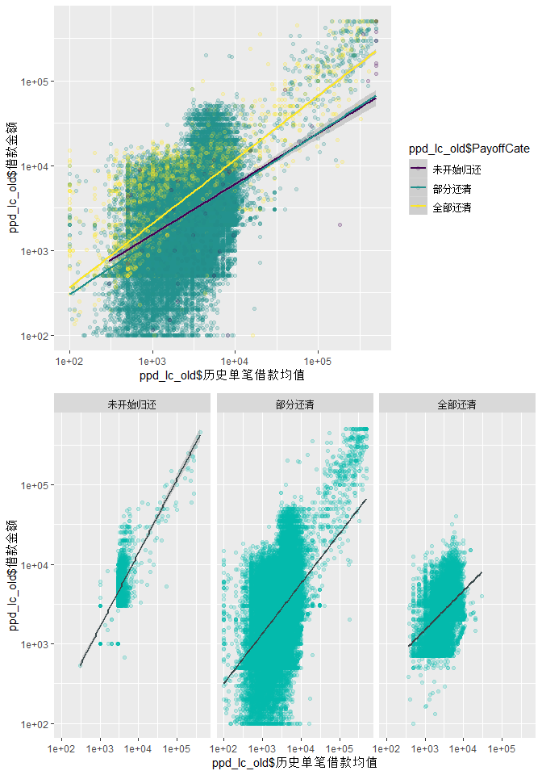

线性关系比较明显。建立模型以评估不同偿还状况对行为的影响：

```r
# https://stackoverflow.com/questions/1169539/linear-regression-and-group-by-in-r
model_lsum_lavg_grouped3 <- df_model %>%
  group_by(PayoffCate) %>%
  do(model = lm(LoanSum ~ Prev.LoanAvg, data = .))

model_lsum_lavg_grouped3$model
```

```
## [[1]]
##
## Call:
## lm(formula = LoanSum ~ Prev.LoanAvg, data = .)
##
## Coefficients:
##  (Intercept)  Prev.LoanAvg
##    1536.1667        0.5873
##
##
## [[2]]
##
## Call:
## lm(formula = LoanSum ~ Prev.LoanAvg, data = .)
##
## Coefficients:
##  (Intercept)  Prev.LoanAvg
##     183.0255        0.9536
##
##
## [[3]]
##
## Call:
## lm(formula = LoanSum ~ Prev.LoanAvg, data = .)
##
## Coefficients:
##  (Intercept)  Prev.LoanAvg
##      2247.76          1.01
```

```
## # A tibble: 6 x 6
## # Groups:   PayoffCate [3]
##   PayoffCate term         estimate std.error statistic  p.value
##   <ord>      <chr>           <dbl>     <dbl>     <dbl>    <dbl>
## 1 未开始归还 (Intercept)  1536.    321.           4.78 1.92e- 6
## 2 未开始归还 Prev.LoanAvg    0.587   0.00809     72.6  0.
## 3 部分还清   (Intercept)   183.     11.5         15.9  1.10e-56
## 4 部分还清   Prev.LoanAvg    0.954   0.00128    748.   0.
## 5 全部还清   (Intercept)  2248.    105.          21.3  1.93e-99
## 6 全部还清   Prev.LoanAvg    1.01    0.00462    219.   0.
```

```
## # A tibble: 3 x 12
## # Groups:   PayoffCate [3]
##   PayoffCate r.squared adj.r.squared  sigma statistic p.value    df  logLik
##   <ord>          <dbl>         <dbl>  <dbl>     <dbl>   <dbl> <int>   <dbl>
## 1 未开始归还     0.780         0.780 12227.     5275.       0     2 -1.61e4
## 2 部分还清       0.712         0.712  4984.   558923.       0     2 -2.24e6
## 3 全部还清       0.776         0.776 12119.    47912.       0     2 -1.50e5
## # ... with 4 more variables: AIC <dbl>, BIC <dbl>, deviance <dbl>,
## #   df.residual <int>
```

### 借款人单笔历史借款均值和总待还金额，与借款人借款金额的线性关系

```
##
## Calls:
## m1: lm(formula = ppd_lc_old$借款金额 ~ ppd_lc_old$历史单笔借款均值,
##     data = ppd_lc_old)
## m2: lm(formula = ppd_lc_old$借款金额 ~ ppd_lc_old$历史单笔借款均值 +
##     ppd_lc_old$Unpaid_Total, data = ppd_lc_old)
## m3: lm(formula = ppd_lc_old$借款金额 ~ ppd_lc_old$历史单笔借款均值 +
##     ppd_lc_old$Unpaid_Total + ppd_lc_old$PayoffRate, data = ppd_lc_old)
##
## =================================================================================================
##                                         m1                    m2                    m3
## -------------------------------------------------------------------------------------------------
##   (Intercept)                            376.393***            509.632***          -1311.579***
##                                          (12.754)              (13.437)              (28.581)
##   ppd_lc_old$历史单笔借款均值              0.936***              0.967***              0.955***
##                                           (0.001)               (0.002)               (0.002)
##   ppd_lc_old$Unpaid_Total                                       -0.049***             -0.037***
##                                                                 (0.002)               (0.002)
##   ppd_lc_old$PayoffRate                                                               37.354***
##                                                                                       (0.519)
## -------------------------------------------------------------------------------------------------
##   R-squared                                0.722                 0.723                 0.729
##   adj. R-squared                           0.722                 0.723                 0.729
##   sigma                                 5853.058              5841.485              5779.714
##   F                                   626495.683            314968.837            216218.792
##   p                                        0.000                 0.000                 0.000
##   Log-likelihood                    -2433479.017          -2433001.360          -2430437.874
##   Deviance                     8259261605422.433     8226599191317.482     8053501045791.012
##   AIC                                4866964.034           4866010.719           4860885.748
##   BIC                                4866995.213           4866052.291           4860937.712
##   N                                   241090                241090                241090
## =================================================================================================
```

### 多变量分析：小结

#### 各业务线的诞生、消亡，及单量变化情况

- 电商业务线可能在2017年1月左右关闭；
- 普通贷款类业务线增长比较平稳
- 主要业务增长由APP闪电产品贡献，2016年4月小额现金贷产品上线后，APP业务迎来大爆发

#### 不同借款类型借款人借款时的待还金额，随时间变化的情况趋势

**模型** - 不同业务线借款人借款时的总待还金额的趋势变化情况，可以用如下模型粗略表示： - APP闪电 ： 7.755681 * 日期距2015年1月1日天数 + -1172.006017 - 电商：275.253290 * 日期距2015年1月1日天数 + -14730.306635 - 普通：1.150758 * 日期距2015年1月1日天数 + 5193.589459 - 其他： 3.677492 日期距2015年1月1日天数 + 3593.983554 - 模型效应量极小，完全不能用于预测实际业务情况，仅能勾勒平台总体的运行趋势。

#### 借款时先前负债的归还情况，对同历史单笔借款均值的借款人借款金额的影响

**模型** - 借款时先前负债的归还情况，对同历史单笔借款均值的借款人借款金额的影响，可以用如下模型粗略表示： - 未开始归还：借款金额 = 0.5873087 * 历史的那笔借款均值 + 1536.1667046 - 部分还清：借款金额 = 0.9536 * 历史的那笔借款均值 + 183.0255295 - 全部还清：借款金额 = 1.0104915 * 历史的那笔借款均值 + 2247.7636012 - 模型效应量较大，能够比较好的说明不同债务水平的借款人的行为差异。

## 疯魔的时代，32万人，和他们的债务泥沼——定稿与总结

### 进击的的闪电贷，夸张的电商贷——借款金额与借款类型随借款时间的演变

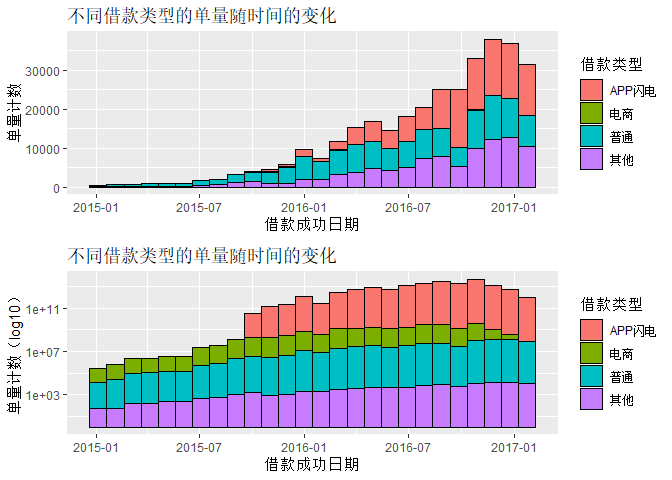

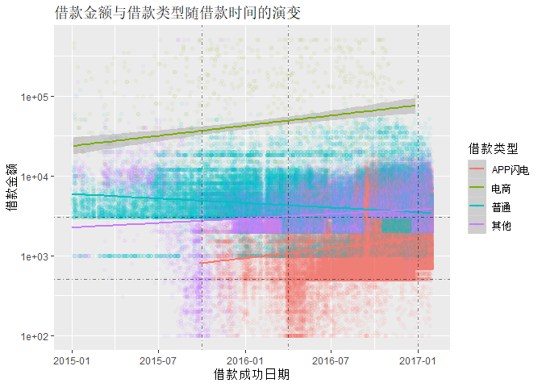

**普通借款业务**

- 普通借款类型有两条显著的水平直线：1000和3000。这两条直线都持续到了2016年3月。原因是，普通借款业务的起始金额就是3000元，或者直接借1000.这一情况随着产品的调整逐渐消失；
- 普通借款业务的趋势线在不断下跌，意味着普通借款业务的人均借款金额在下降。

**APP闪电业务**

- 这里所谓的APP闪电，指的应该是拍拍贷旗下手机PPP闪电贷上的所有业务类型，而并非专指闪电小额贷款业务；
- APP闪电自2015年10月1日开始出现，并自2016年4月1日其密度明显提高，并在5月，在500元的出现明显的水平直线；
- 2016年4月1日其密度明显提高这一细节，与拍拍贷[招股书](https://www.sec.gov/Archives/edgar/data/1691445/000119312517309953/d285990df1.htm)中提到的如下细节吻合：2016年4月，上线小额闪电借款业务，额度低，秒放款成为主要卖点；
- 15年10月开始出现闪电贷APP的细节并不清楚，招股书并未给予说明；
- 2016年5月，可能其闪电小额贷款业务出现了调整，起始贷款下限提升为500元，导致了一条明显的水平线
- APP闪电业务的借款金额在快速上涨，从点阵上看密度惊人，但整体金额上仍低于普通借款业务；这可能意味着额度小，放款快，灵活度高的接待产品有着相比传统借款业务明显更高的使用频次

**电商业务**

- 电商业务自2017年1月1日后就再也没出现过；[招股书](https://www.sec.gov/Archives/edgar/data/1691445/000119312517309953/d285990df1.htm)上对此业务也没有说明；可能此项业务已经停止；
- 电商业务的借款金额随着时间流逝一直在快速上涨；
- 根据第三方网站融360的信息，拍拍贷确实曾有过针对电商老板的个人贷款，其并不局限于淘宝店主。（https://www.rong360.com/p_a3s36c627）（https://www.rong360.com/content/a3u313f3v）
- 结合利率和期限可知，电商业务主要为短期大额贷款，利率也相对较低

**其他业务**

- 具体指代不明，可能是其他消费贷款业务
- 其他业务的单量和借款金额一直在缓慢上涨

**小结与模型**

### 胃口大开的平台，越借越穷的借款人和压力山大的电商老板

- 总体来看，拍拍贷平台借款人借款时的平均负债水平保持稳定

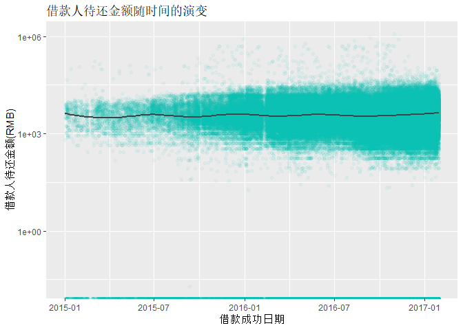

- 尽管平均水平稳定，其各业务线的借款人在借款时负担的债务越来越多却也是不争的事实

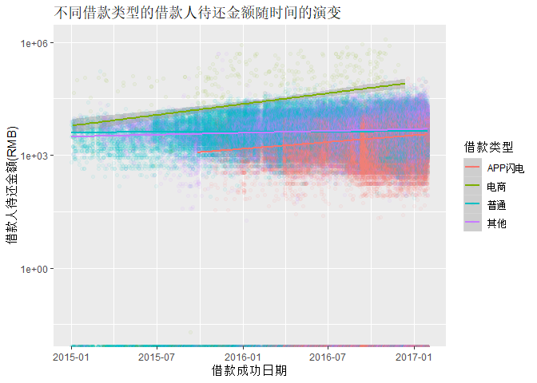

- 其中，电商业务借款人的债务负担飞速上涨。 - APP闪电产品的借款人债务水平上涨也较为快速。

- 尽管效应量极低且不建议用于预测，我们的模型显示了借款人债务负担的整体演变趋势，细节如下：
  - APP闪电 ： 7.755681 * 日期距2015年1月1日天数 - 1172.006017
  - 电商：275.253290 * 日期距2015年1月1日天数 - 14730.306635
  - 普通：1.150758 * 日期距2015年1月1日天数 + 5193.589459
  - 其他： 3.677492 日期距2015年1月1日天数 + 3593.983554
- 还有一些额外的信息值得关注：
  - 随着时间推移，拍拍贷借款人借款时，待还旧债占整体债务的比例越来越高

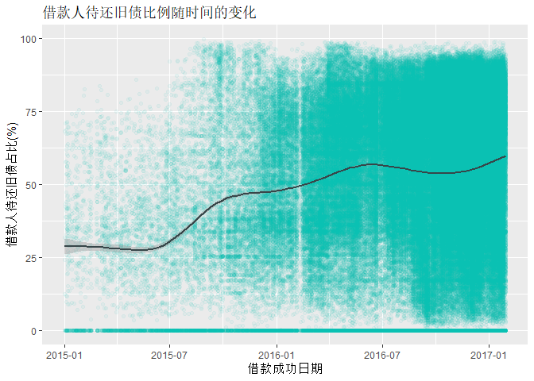

- 随着时间的流逝，举债借款，以及还未归还就借款就接入新借款的用户越来越多

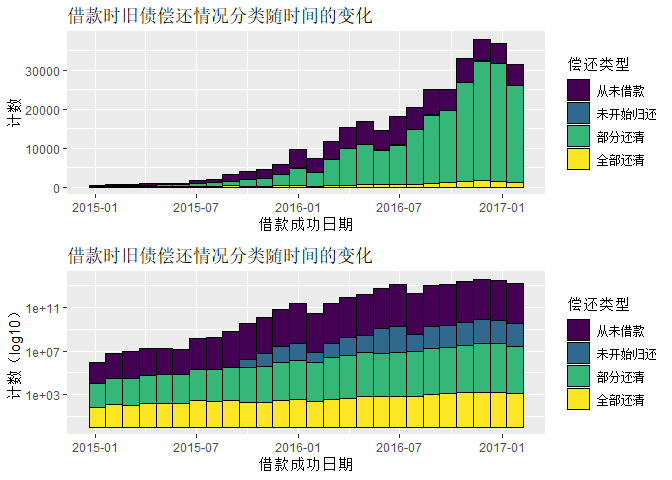

### 借都借了，接着借呗！——借款人的借款金额都与其历史借款的平均数高度相关

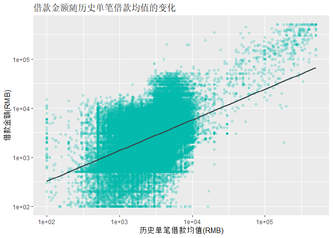

- 线性回归模型显示：借款金额 = 0.936 * 借款人单笔历史借款均值 + 376.393
- 其他有相关性的参数，如总待还金额等，与上述模型有共线性；在经历一些尝试后我们没有找到更合适的参数

### 有借有还，多借不难！——还清旧债的借款人借的更多

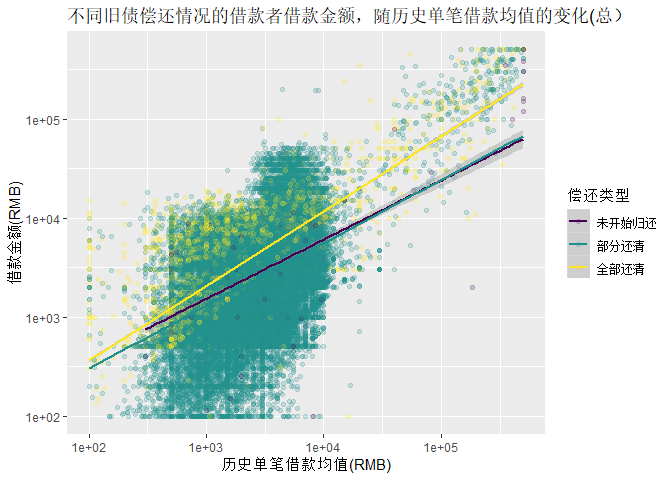

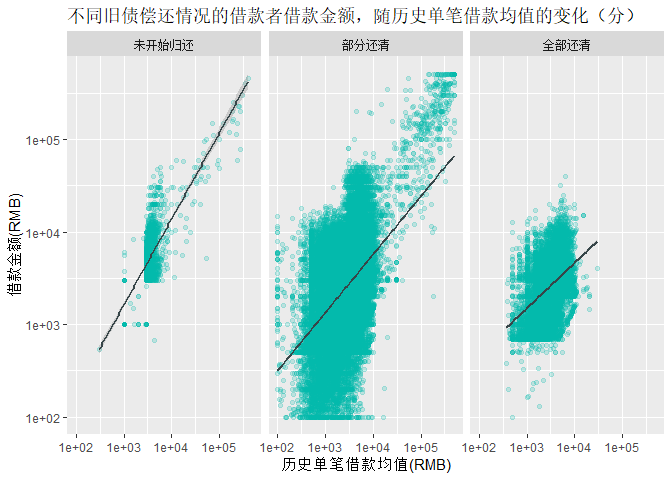

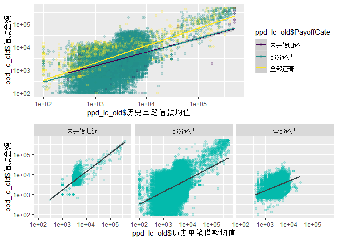

### 总结：债务、贫穷、稀缺和闲余———疯魔的时代，32万人，和他们的债务泥沼

2015-2017年是疯魔的两年，也是P2P平台在经历第一批暴雷潮后突飞猛进的两年。诚然，P2P，或是互联网金融，抑或是消费/普惠金融，其诞生和发展有其原生动力：大量被排除在主流金融机构，囊中羞涩却又有十分强劲消费欲望的年轻群体，亦或是我们发现的，寻求短期过桥资金的小企业老板。

但就在消费金融的发展突飞猛进的同时，消费升级的概念也被频频打出，不断地吸引人们消费。当然，这些行为本身无可厚非，资本就为逐利施加诱惑，人类的天性又追求短期享受而非长期利益，都是正常的行为。更何况，作为合格的社会公民，永续消费就是我们应尽的义务。

但对于个人来说，最为可怕的，还是借款是个潘多拉的魔盒这个结论：我们看到，借款人会借入跟他们平均借款量相当的新借款；借款人们负债不断加重，以债养债的人不断增加；还清了借款的人借入了更多的款项……尽管具体原因尚未可知，但我们不难做出这样的判断：拍拍贷们商业成功的背后，人们正在为他们的行为付出代价。

穆莱纳森在他的《稀缺》中，观察到印度甘蔗农不得不贷款，但也越借越穷的现象；在他的实验中，就算他帮助印度的农民还清债务，这些农民也会逐渐陷入贫困。这似乎是借贷与贫穷的诅咒。但破解的办法也非常简单：存钱。在手有余钱的时候，撇出10%存下应急资金，然后忘掉他们，10%的资金也不会影响生活质量——应对稀缺的唯一办法，就是适度的闲余。

看着[拍拍贷的百度百科](https://wapbaike.baidu.com/item/拍拍贷)骄傲又自豪的宣称：“复借率较去年同期提升了2.4%达到69.8%”。我明白商业不讲对错，可这真的是一件值得骄傲的事情吗？不过商业道德问题，我们就不在这里展开了。

**默默攒钱，理性消费**——这个祝愿，给我自己，也给看到这份报告的每一个人。

# 反思

首先我承认，这篇作业做的比较赶——许多变量的更深入探索没有来得及做，对数据集的了解程度，和对R语言的了解的拓展程度也远远比不上之前的两个用python的大项目——以至于这篇报告几乎每一段代码都有warning。一方面时因为用R实在不是什么愉快的体验，一方面是因为懒，一方面是觉得没必要花太长的时间（虽然到现在也已经5天了），最后还是因为春节。代码质量，函数复用什么的，真的顾不上了。

还有很多潜在的，可能很有意思的方向有待挖掘：各种认证对借款行为或者守信行为会不会有影响？总放贷额度变化情况如何？当然，我们在最后提出的一些问题也可以深入的挖掘：为什么借款人会连续借款？为什么债务还清了的人会借更多钱？方向真的很多~

这个数据集可以挖掘的信息实在太多了，它还有两个数据集，一个记录了这个数据集里的所有标的的还款情况，还有一个投资人的标的可以用于涉及风控模型。因此，最大的困难其实是决定要深入挖掘哪些，放弃哪些数据。好在，这个数据集除了风控之外还可以提出新的方向，数据之间的关系也很容易挖掘，稍加思考（只要不像知乎某答主那样那么不走心），可能还是能看的。

当然，我也会尝试着甩锅给我选择的数据集：这个数据集是中文，而R在面对中文时似乎容易出现很多匪夷所思的问题。或许Python也是。如果要重来一遍，我可能会选择在开始就把列名全部换成英文。莫名其妙的报错真的令人欲哭无泪。

虽然ggplot在绘图方面比python的matplotlib好理解太多，但是文档看着让我非常费解——许多变量不知道是干嘛的，也没有详细的说明（或者说说明太抽象了），更多变量直接用省略号代替了，还有些变量似乎根本不在文档里。

别的，也就是探索拍拍贷的借款人们负债状况的时候的冲击感吧——我为什么之前不攒攒钱，我的花呗欠款为什么那么多，还有，老东家欠下的薪水估计这辈子都要不回来了，哎，当时为啥脑子一抽没有及时离职呢……

**默默攒钱，理性消费**，坚守道德底线，共勉吧~

# 一些问题

好吧，说来说去其实就一个：R对中文的支持怎么这么烂~

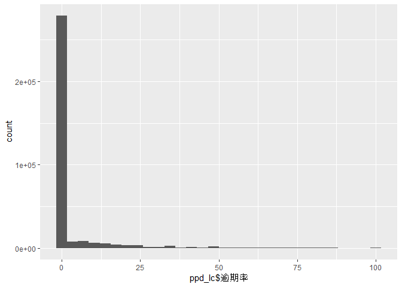

```r
# 为什么这一段代码就死活画不出来呢（在RStudio里）
ggplot(aes(x = ppd_lc$'逾期率'), data = ppd_lc) +
  geom_histogram()
```

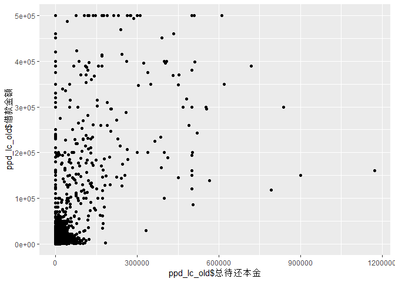

```r
# 问题同上，为什么这张图就死活画不出来，列复制一下就没问题了呢（在RStudio里）
ggplot(data = ppd_lc_old,
       aes(x = ppd_lc_old$"总待还本金", y = ppd_lc_old$"借款金额")) +
  geom_point()
```

```r
# 为什么这样抽样会产生大量的NA?
set.seed(250)
ppd_samp1 <- ppd_lc[sample(1: length(ppd_lc$ListingId), 10000), ]
```